# Pulse programming in TopSpin, part 6

nmr

pulse programming

Published

July 23, 2023

Here, we’ll introduce *pulsed field gradients*, which are ways of temporarily creating a magnetic field with a fixed amount of inhomogeneity.

These are ubiquitous in modern NMR experiments, where their main purpose is to select specific types of desired magnetisation and to reject (dephase) all other magnetisation. We will see how this works using a simple spin echo experiment.

*(This is part 6 of a series of posts on pulse programming in TopSpin. For the other parts, see the table of contents here.)*

# The spin echo sequence

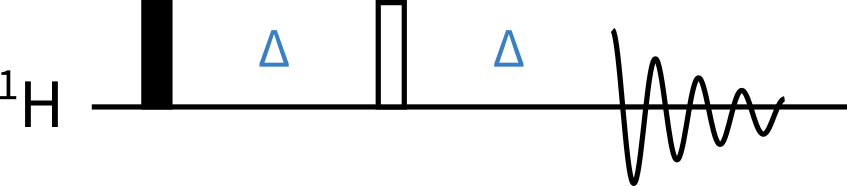

The spin echo pulse sequence.

A *spin echo* refers to a 180° pulse bracketed by two delays of equal length; so, technically, the sequence depicted above consists of an excitation pulse followed by a spin echo sequence. By now, you might have enough knowledge to write a pulse programme for the above: I encourage you to have a go at it. The flip angle for the excitation pulse can be restricted to 90°.

Recall that `p1` should always correspond to the 90° pulse width; and note that, by convention, `p2` is used for the 180° pulse width. Since `d1` is already taken for the recovery delay, we can use `d2` for the spin echo delay denoted by $\Delta$ above. That should define all the necessary variables for the pulse programme.

Here’s my version. One thing worth noting is that I explicitly specified that `p2` is to be double of `p1`, using the line `p2 = p1 * 2`. This makes it clearer what `p2` means and also makes sure that there is *absolutely* no possibility of getting it wrong.

```
; jy_spinecho
; excitation, then spin echo
; Jonathan Yong, 19 July 2021

#include <Avance.incl>

"p2 = p1 * 2"

ze
1 d1
(p1 ph1):f1
d2
(p2 ph1):f1
d2
go=1 ph31
wr #0
exit

ph1 = 0 2
ph31 = 0 2

;p1    : 90 degree pulse width (from getprosol)
;pl1   : hard pulse power (from getprosol)
;p2    : 180 degree pulse width
;d1    : recovery delay (ca. 1 s)
;d2    : spin echo delay
```

Type `ased` to get to the parameter screen. Set `d2` to something short, on the order of 10 ms.

## A note about units

Delays are specified in *seconds*, so if you want 10 ms, you need to enter `0.010`, *not* `10`. On the other hand, pulses are specified in *microseconds*, so if you want a 10 ms pulse you would need to enter `10000`. **Forgetting these units is an extremely common source of error!**

To avoid this, in the `ased` screen and elsewhere in TopSpin, you can explicitly enter the units. When entering units, seconds are specified using `s`, milliseconds using `m`, and microseconds with `u`. Thus, instead of entering `0.010`, you could also enter `10m`. You should give this a try: notice how when you input `10m` and press `Enter`, it automatically gets changed to `0.010`.

This technique can be used for both delays and pulses. We haven’t yet come across any pulses that are longer than a few microseconds, but in the next post we will meet *shaped pulses* which are typically on the order of milliseconds.

## Running the experiment

Run the experiment and process it. You should see some distorted multiplets like the following (if your sample doesn’t have any multiplets, you’d need to look for a more complicated sample).

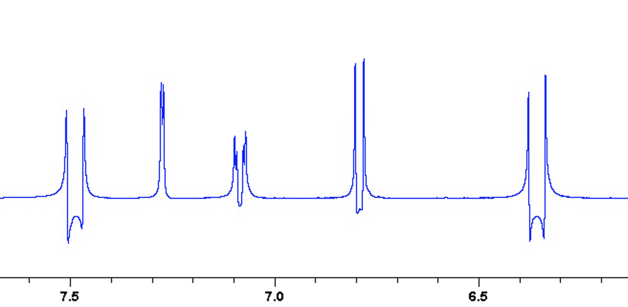

Distorted multiplets arising from the spin echo sequence.

(If you are familiar with product operators, you should quickly convince yourself as to why these multiplets are distorted—or in other words, not purely in phase.)

# Adding gradients on either side

The job of the 180° pulse in the spin echo is to refocus chemical shift evolution. This is great as long as the 180° pulse is *perfect*: however, what happens if there are significant off-resonance effects (meaning that the edges of the spectrum aren’t refocused properly), or if the pulse is miscalibrated (meaning that it actually isn’t really a 180° flip angle)?

Adding some proper phase cycling can solve these issues, but that forces you to record more scans than you might need or want to. A more direct solution is to surround the 180° pulse with a pair of gradients which have equal magnitude, which *refocus* the desired coherence transfer pathway and *dephase* all others. (If you have read the requisite chapter of Keeler’s book, the desired pathway here is $+1 \to -1$.)

Gradients are specified using the syntax `pX:gpY`, where `pX` is the duration of the gradient and `gpY` specifies both the *shape*[^1] as well as the *amplitude* of the gradient. A very important thing to note about gradients is that **every gradient should be followed by a short delay**, conventionally labelled `d16`, which allows for the dissipation of *eddy currents*. Thus, at every point in a sequence where a gradient is to be inserted, you need to add *two* lines: one `pX:gpY` for the actual gradient itself, and `d16` immediately after that. An appropriate value of `d16` would be somewhere around 200 µs.

For “standard” CTP-selection gradients, `X` is typically chosen to be 16. Let’s choose `Y` to be 1. Our pulse sequence should now become something like the following. (You don’t have to make a new sequence if you don’t want to; it’s OK to just overwrite the current one.) CTP gradient durations, i.e. `p16` in our case, are often set to 1 ms, so set this value in the `ased` screen before moving on.

```
; jy_spinecho
; excitation, then spin echo, with gradients
; Jonathan Yong, 19 July 2021

#include <Avance.incl>
#include <Grad.incl>

"p2 = p1 * 2"

ze
1 d1
(p1 ph1):f1
d2
p16:gp1
d16
(p2 ph1):f1
d2
p16:dp1
d16
go=1 ph31
wr #0
exit

ph1 = 0 2
ph31 = 0 2

;p1    : 90 degree pulse width (from getprosol)
;pl1   : hard pulse power (from getprosol)
;p2    : 180 degree pulse width
;d1    : recovery delay (ca. 1 s)
;d2    : spin echo delay
;p16   : CTP gradient duration (1 ms)
;d16   : gradient recovery delay (ca. 200 us)
;gpz1  : 10% (CTP gradient)
;gpnam1: SMSQ10.100
```

## Parameter descriptions

As before, we might want to include some extra comments at the bottom of the pulse programme which are displayed in the `ased` screen. Each gradient `gpZ` actually has four parts to it: the *name* of the gradient `gpnamZ`, the *$x$-amplitude* `gpxZ`, the *$y$-amplitude* `gpyZ`, and the *$z$-amplitude* `gpzZ`. The name `gpnamZ` refers to a file, which in turn specifies the shape of the gradient; so `gpnamZ` can indirectly be thought of as the shape of the gradient. The three different amplitude components refer to the axis along which the field inhomogeneity is applied (conventionally, $z$ refers to the vertical axis in the laboratory frame). These are specified in terms of percentages of the maximum permissible field gradient: thus, you should *never* exceed 100%![^2]

Many standard probes can only do $z$-gradients, which forces `gpx` and `gpy` to be both zero; thus, it is quite common to write comments for only the `gpz` and `gpnam` components.

In principle, you can put any text you like as the parameter description: after all, it’s just a comment. But practically speaking, there is a Python script bundled with TopSpin called `gppp.py`: this script *reads* the parameter descriptions from the pulse programme and sets the values of `gpnam` and `gpz` accordingly, which is quite convenient.[^3] In order for this script to work, you have to specify these in a particular format. The simplest possibility is to simply set the parameter description to the value that these parameters should take.

```
;gpz1  : 10%
;gpnam1: SMSQ10.100
```

Alternatively, you can add some descriptive text behind the `gpz` values to tell the user what the role of the gradient is.

```
;gpz1  : 10% (CTP gradient)
;gpnam1: SMSQ10.100
```

In any case, you should add these to your pulse programme if you haven’t already. Then, go to the `ased` screen, and type `gppp` into the TopSpin command line. The chosen values for `gpz1` and `gpnam1` should be automatically populated.

Run the spectrum; you should see that this is not very different from before. (In other words, the 180° pulse should have been pretty close to perfect.) However, with more complicated experiments, it is definitely possible to observe improvements in spectral quality.

# Fixing the spin echo delay

If you have very keen eyes (or used multiple-display mode!), you might have noticed that when you added gradients in, the multiplets became slightly more distorted than before. The reason for this is because when you added in the gradients, the *total* spin echo delay is no longer just `d2`, but instead `d2 + p16 + d16`. This leads to a slightly longer period where J-coupling is allowed to evolve, and hence more distorted multiplets.

```
"d3 = d2 - p16 - d16"
```

In this case, the spin echo delay is a pretty arbitrary number and you could argue that it doesn’t really matter whether an extra `p16 + d16` is tacked on. However, in most pulse sequences, the total delay matters quite a bit: for example, it might have to be an exact multiple of $1/J$ where $J$ is some coupling of interest.

# Gradient blanking

A final, small technical detail involves so-called *gradient blanking*, which refers to the isolation of the gradient-generating electronics from the rest of the probe. Without going into too much detail, it is generally a good idea to **unblank** the gradient system when you want to create gradients, and **blank** the system when you don’t.

These can be accomplished with, respectively, the `UNBLKGRAD` and `BLKGRAD` statements. However, these statements aren’t available by default. You might recall, at the very beginning, we mentioned how all pulse programmes must include the line `#include <Avance.incl>`. It turns out that to get these two gradient blanking commands, we need to also include the `Grad.incl` file; so you need to add a new line near the top of the pulse programme saying `#include <Grad.incl>`.

Where do we place them, then? `UNBLKGRAD` is the easy one: we should place that just before our first gradient. On the other hand, `BLKGRAD` should be put at some point in the pulse programme when we’re *done* with the gradients. In theory, this means just prior to acquiring the FID. However, on some systems this can cause some issues with the spectrometer lock mechanism. If the lock system isn’t stable during acquisition, this can cause peaks to “drift” in frequency, and it is sometimes possible to observe this as a shifted peak in the spectrum. So, I generally prefer to put `BLKGRAD` just before the recovery delay (which equates to just after the FID of the previous scan is acquired).

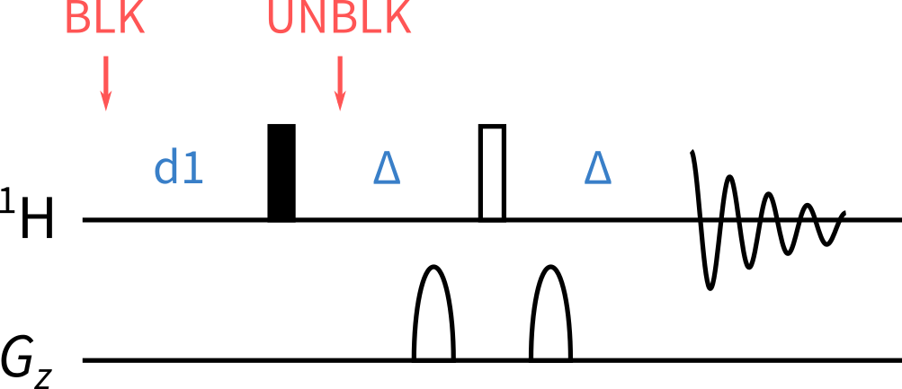

The spin echo pulse sequence, with gradient blanking.

Both `UNBLKGRAD` and `BLKGRAD` need to be specified together with some delay. In this case, it’s quite convenient in that we can specify `UNBLKGRAD` together with the `d3` delay, and we can specify `BLKGRAD` together with the `d1` delay.

As a final note, we should also perform a final `BLKGRAD` at the end of the pulse sequence, just before the `exit` statement. This can’t be tacked onto an existing delay (there isn’t one in the right place), so we can create one specifically for it: but instead of writing something like `d11 BLKGRAD` and *then* specifying the value of `d11`, we can directly hard-code the delay duration by writing `50u BLKGRAD`. (Recall that `u` in TopSpin corresponds to microseconds.)

The final pulse programme for this section should look like this:

```
; jy_spinecho
; excitation, then spin echo, with gradients
; Jonathan Yong, 19 July 2021

#include <Avance.incl>
#include <Grad.incl>

"p2 = p1 * 2"
"d3 = d2 - p16 - d16"

ze
1 d1 BLKGRAD
(p1 ph1):f1
d3 UNBLKGRAD
p16:gp1
d16
(p2 ph1):f1
d2
p16:dp1
d16
go=1 ph31
wr #0
50u BLKGRAD
exit

ph1 = 0 2
ph31 = 0 2

;p1    : 90 degree pulse width (from getprosol)
;pl1   : hard pulse power (from getprosol)
;p2    : 180 degree pulse width
;d1    : recovery delay (ca. 1 s)
;d2    : desired spin echo delay
;d3    : actual delay (after subtracting p16 and d16)
;p16   : CTP gradient duration (1 ms)
;d16   : gradient recovery delay (ca. 200 us)
;gpz1  : 10% (CTP gradient)
;gpnam1: SMSQ10.100
```

If you made it all the way here, congratulations! This was a fairly long post. In the next post we’ll do a short exercise to consolidate everything we’ve learnt so far.

## Footnotes

[^1]: The shape basically specifies how fast the gradient is to be turned on and off. In practice we almost exclusively use smoothed gradients which “ramp up” at the beginning slowly from 0, and “ramp down” at the end.
[^2]: What *is* the maximum permissible field gradient? You can type the `edprobe` command in TopSpin to find out. From the resulting box, select the probe you are currently using (consult someone if you’re not sure what you’re doing). Double-click on it: if it asks you for an admistration password, click Cancel. In the resulting list of parameters, you should notice the *“maximum gradient strength in Z direction”* in units of G/(cm A), and the *“maximum permissible current in Z direction”* in units of A. The maximum gradient strength in G/cm is then the product of these two quantities.
[^3]: To see what’s in this Python script, you can type `edpy gppp` in the TopSpin command line.